# Assignment9

Liam

11/4/2019

```r
library(tidyverse)
library(caret)
titanic<-read_csv("C:\\Users\\student\\Desktop\\Fall2019\\R\\titanic.csv")
titanic<-data.frame(titanic)%>%
  rename(target = Survived) %>%
  select(-c(Name, Ticket, Cabin, PassengerId))%>%
  drop_na
titanic$target <- factor(titanic$target)
```

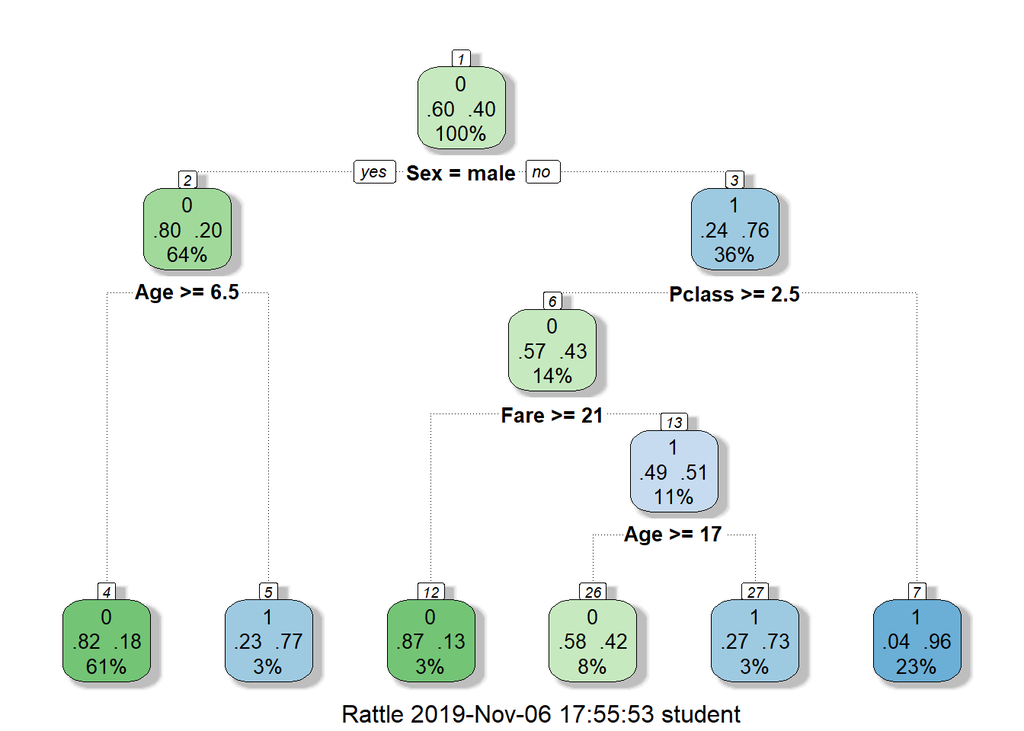

```r
# Split the data into 70% training and 30% testing

splitIndex <- createDataPartition(titanic$target, p = .70, list = FALSE)
train <- titanic[ splitIndex,]
test <- titanic[-splitIndex,]

library(rpart) #load the rpart package

# build a tree
mytree <- rpart(target ~ ., data = train, method = "class")

# Plot the tree
library(rattle)
fancyRpartPlot(mytree)
```

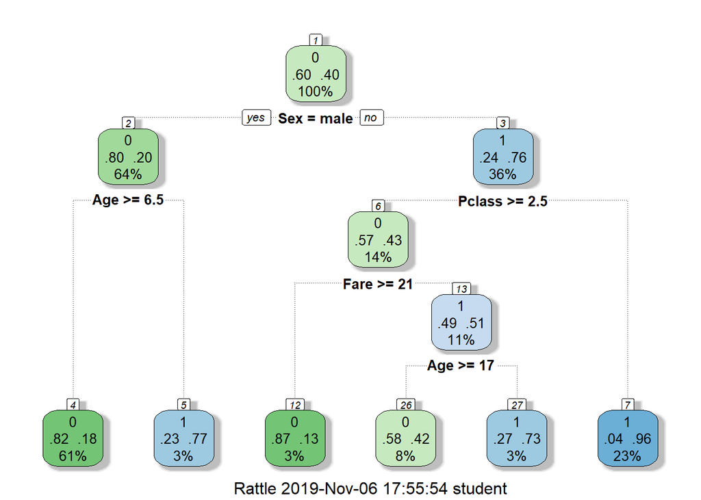

```r
# Evaluate the tree on the testing data

#predict on testing data
pred <- predict(mytree, test, type = "class")

#Evaluate the predictions
cm=confusionMatrix(data = pred, reference = factor(test$target), positive = "1")

# build a tree
mytree <- rpart(target ~ ., data = train, method = "class")

# Plot the tree
library(rattle)
fancyRpartPlot(mytree)
```

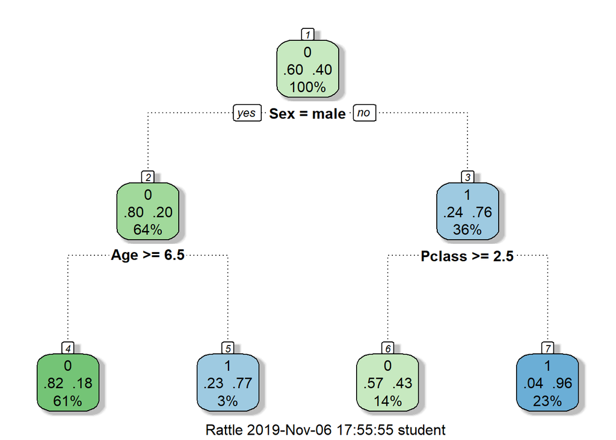

```r
# Evaluate the tree on the testing data

#predict on testing data
pred <- predict(mytree,test, type = "class")

#Evaluate the predictions
cm=confusionMatrix(data = pred, reference = factor(test$target), positive = "1")

# Build another tree
# Tree with depth=2
mytree2 <- rpart(target ~ ., data = train, method = "class", control = rpart.control(maxdepth = 3))
fancyRpartPlot(mytree2)
```

Compute the training error of a decision tree with maxdepth=1

```r
thetree <- rpart(target ~ ., data = train, method = "class", control = rpart.control(maxdepth = 1))
predthetree <- predict(thetree, train, type = "class")
confusionMatrix(data = predthetree, reference = factor(train$target), positive = "1")$overall["Accuracy"]
```

```
##  Accuracy
## 0.7815631
```

Compute the training errors of decision trees with maxdepth running from 1 to 10. How does the training error change when the maxdepth increases.

```r
for (n in 1:10) {
  thetree <- rpart(target ~ ., data = train, method = "class", control = rpart.control(maxdepth = n))
  predthetree <- predict(thetree, train, type = "class")
  print(paste("Max Depth = ", n, " Accuracy = ", confusionMatrix(data = predthetree, reference = factor(train$target), positive = "1")$overall["Accuracy"]))
#  print(confusionMatrix(data = predthetree, reference = factor(train$target), positive = "1")$overall["Accuracy"])
}
```

```
## [1] "Max Depth =  1  Accuracy =  0.781563126252505"
## [1] "Max Depth =  2  Accuracy =  0.81563126252505"
## [1] "Max Depth =  3  Accuracy =  0.81563126252505"
## [1] "Max Depth =  4  Accuracy =  0.829659318637275"
## [1] "Max Depth =  5  Accuracy =  0.829659318637275"
## [1] "Max Depth =  6  Accuracy =  0.829659318637275"
## [1] "Max Depth =  7  Accuracy =  0.829659318637275"
## [1] "Max Depth =  8  Accuracy =  0.829659318637275"
## [1] "Max Depth =  9  Accuracy =  0.829659318637275"
## [1] "Max Depth =  10  Accuracy =  0.829659318637275"
```

Compute the test errors of decision trees with maxdepth running from 1 to 10. How does the test error change when the maxdepth increases.

```r
for (n in 1:10) {
  thetree <- rpart(target ~ ., data = train, method = "class", control = rpart.control(maxdepth = n))
  predthetree <- predict(thetree, test, type = "class")
 # print(paste("Max Depth = ", n))
  print(paste("Max Depth = ", n, " Accuracy = ", confusionMatrix(data = predthetree, reference = factor(test$target), positive = "1")$overall["Accuracy"]))
}
```

```
## [1] "Max Depth =  1  Accuracy =  0.774647887323944"
## [1] "Max Depth =  2  Accuracy =  0.769953051643192"
## [1] "Max Depth =  3  Accuracy =  0.769953051643192"
## [1] "Max Depth =  4  Accuracy =  0.793427230046948"
## [1] "Max Depth =  5  Accuracy =  0.793427230046948"
## [1] "Max Depth =  6  Accuracy =  0.793427230046948"
## [1] "Max Depth =  7  Accuracy =  0.793427230046948"
## [1] "Max Depth =  8  Accuracy =  0.793427230046948"
## [1] "Max Depth =  9  Accuracy =  0.793427230046948"
## [1] "Max Depth =  10  Accuracy =  0.793427230046948"
```

Parameter tuning is the process to find out the best selection for the parameter. What would be the best selection of the parameter maxdepth?

```r
# Building random forest using ranger


# import the ranger library
library(ranger)
#train a forest of 10 trees and consider a random of 3 variables at each split
model = ranger(factor(target) ~., data = train, mtry = 1, num.trees = 10)

# predict and test on the test dataset
pred3  = predict(model, data = test)$predictions

# Get the confusion matrix
confusionMatrix(factor(pred3), factor(test$target), positive="1")
```

```
## Confusion Matrix and Statistics
##
##           Reference
## Prediction   0   1
##          0 121  43
##          1   6  43
##
##                Accuracy : 0.77
##                  95% CI : (0.7075, 0.8247)
##     No Information Rate : 0.5962
##     P-Value [Acc > NIR] : 6.551e-08
##
##                   Kappa : 0.4865
##
##  Mcnemar's Test P-Value : 2.706e-07
##
##             Sensitivity : 0.5000
##             Specificity : 0.9528
##          Pos Pred Value : 0.8776
##          Neg Pred Value : 0.7378
##              Prevalence : 0.4038
##          Detection Rate : 0.2019
##    Detection Prevalence : 0.2300
##       Balanced Accuracy : 0.7264
##
##        'Positive' Class : 1
##
```

Compute the training errors of random forest with mtry running from 1 to its maximum and num.trees running from 1 to 20.

```r
dat<-data.frame()
for (n in 1:7) {
  for (m in 1:20){
    model = ranger(factor(target) ~., data = train, mtry = n, num.trees = m)
    pred3  = predict(model, data = train)$predictions
    data_frame=data.frame("mtry"= n, "num.trees" = m, "Accuracy"=confusionMatrix(factor(pred3), factor(train$target), positive="1")$overall["Accuracy"])
    dat<-rbind(dat,data_frame)

  }
}

dat<-dat%>%
      select(c(mtry,num.trees,Accuracy))%>%
      arrange(-Accuracy)
rownames(dat)<-c()

print(head(dat))
```

```
##   mtry num.trees  Accuracy
## 1    6        19 0.9879760
## 2    7        17 0.9879760
## 3    6        13 0.9839679
## 4    6        14 0.9839679
## 5    6        15 0.9839679
## 6    6        17 0.9839679
```

Compute the test errors of random forest with mtry running from 1 to its maximum and num.trees running from 1 to 20.

```r
dat<-data.frame()
for (n in 1:7) {
  for (m in 1:20){
    model = ranger(factor(target) ~., data = train, mtry = n, num.trees = m)
    pred3  = predict(model, data = test)$predictions
    data_frame=data.frame("mtry"= n, "num.trees" = m, "Accuracy"=confusionMatrix(factor(pred3), factor(test$target), positive="1")$overall["Accuracy"])
    dat<-rbind(dat,data_frame)

  }
}

dat<-dat%>%
      select(c(mtry,num.trees,Accuracy))%>%
      arrange(-Accuracy)
rownames(dat)<-c()

print(head(dat))
```

```
##   mtry num.trees  Accuracy
## 1    2        16 0.8262911
## 2    2        18 0.8262911
## 3    2        19 0.8215962
## 4    2        12 0.8169014
## 5    2        17 0.8169014
## 6    1        17 0.8122066
```

```r
adult<-read_csv("C:\\Users\\student\\Desktop\\Fall2019\\R\\adult.csv")
```

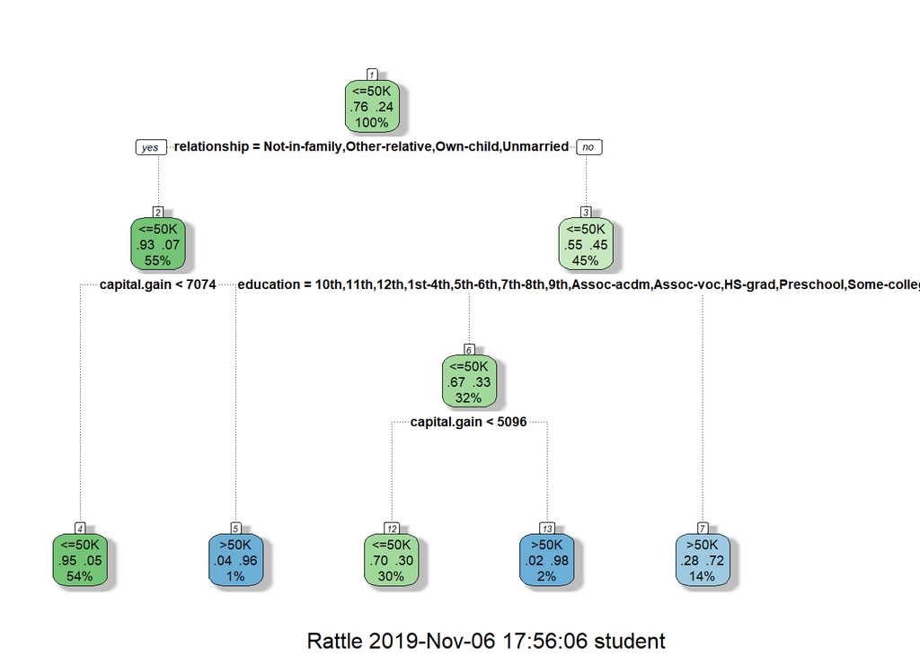

```r
adult<-adult %>%
  drop_na %>%
  rename(target=income)

splitIndex <- createDataPartition(adult$target, p = .70, list = FALSE)
train <- adult[ splitIndex,]
test <- adult[-splitIndex,]




adultTree <- rpart(target ~ ., data = train, method = "class", control = rpart.control(maxdepth = 5))
fancyRpartPlot(adultTree)
```

```r
pred <- predict(adultTree, test, type = "class")
confusionMatrix(data = pred, reference = factor(test$target), positive = ">50K")$overall["Accuracy"]
```

```
##  Accuracy
## 0.8428542
```

```r
datRF<-data.frame()
#for (q in c("gini", "extratrees")) { "splitrule" = q, splitrule = q
  for (n in 1:5) {
    for (m in 1:5) {
      model = ranger(factor(target) ~., data = train, mtry = n, min.node.size = m)
      predNM  = predict(model, data = test)$predictions
      data_frame=data.frame("mtry"= n, "min.node.size" = m, "Accuracy"=confusionMatrix(factor(predNM), factor(test$target), positive=">50K")$overall["Accuracy"])
      datRF<-rbind(datRF,data_frame)
    }
  }
#}

datRF<-datRF%>%
      select(c(mtry,min.node.size,Accuracy))%>%
      arrange(-Accuracy)
rownames(datRF)<-c()
print(head(datRF))
```

```
##   mtry min.node.size  Accuracy
## 1    3             4 0.8662981
## 2    3             2 0.8650696
## 3    3             1 0.8649672
## 4    3             3 0.8649672
## 5    3             5 0.8647625
## 6    2             4 0.8632269
```

Note that: splitrule=gini Gini Index is used to decide the best split at nodes splitrule=extratrees: Split is decided randomly with no rules. This is an idea of the Extreme Randomized Tree https://link.springer.com/article/10.1007/s10994-006-6226-1